# Midterm Assignment: R&D Attrition by Dev Sharma

### Monthly Income

```python
# let's learn the mean monthly income along with other descriptive stats for monthly income
data.MonthlyIncome.describe()
```

```
count      961.000000
mean      6281.252862
std       4895.835087
min       1009.000000
25%       2741.000000
50%       4374.000000
75%       7655.000000
max      19999.000000
Name: MonthlyIncome, dtype: float64
```

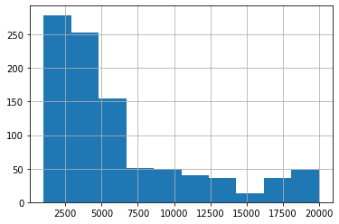

```python
# Let's look at the histogram for monthly income as well
data.MonthlyIncome.hist()
```

Most folks seem to be making around $4300 in a given month

### Educational Field

```python
# Over 80% of the employees have either a Life Sciences or a Medical field for their education
data.EducationField.value_counts(normalize=True)
```

```
Life Sciences       0.457856
Medical             0.377732
Technical Degree    0.097815
Other               0.066597
Name: EducationField, dtype: float64
```

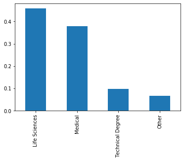

```python
# plotted
data.EducationField.value_counts(normalize=True).plot.bar()
```

# 3. Data Support for R&D Head's Assertion

*Do the data support the assertion of the head of R&D (i.e. the relationship between experience and performance)? Explain why or why not. (10 points)**

```python
# Most folks fall under the level 3 or 4
data.PerformanceRating.value_counts()
```

```
3    805
4    156
Name: PerformanceRating, dtype: int64
```

```python
def perf_vs_exp(exp_metric):
    print(f"Let's take a look at how {exp_metric} varies based on Performance Rating")
    print("\n")
    print("When the rating is 3:")
    print(data[data.PerformanceRating==3][exp_metric].describe())
    print("\n")
    print("When the rating is 4:")
    print(data[data.PerformanceRating==4][exp_metric].describe())
    print("\n")
    print("Now let's see what this relationship looks like plotted")
    print(data.boxplot(by="PerformanceRating", column=exp_metric,return_type="both"))
```

## Plotting Experience vs. Performance Score

### Years At Company

```
Let's take a look at how YearsAtCompany varies based on Performance Rating


When the rating is 3:
count    805.000000
mean       6.973913
std        6.172928
min        0.000000
25%        3.000000
50%        5.000000
75%        9.000000
max       40.000000
Name: YearsAtCompany, dtype: float64


When the rating is 4:
count    156.000000
mean       6.301282
std        5.169913
min        0.000000
25%        2.000000
50%        5.000000
75%        9.250000
max       23.000000
Name: YearsAtCompany, dtype: float64


Now let's see what this relationship looks like plotted
YearsAtCompany    (AxesSubplot(0.1,0.15;0.8x0.75), {'whiskers': ...
dtype: object
```

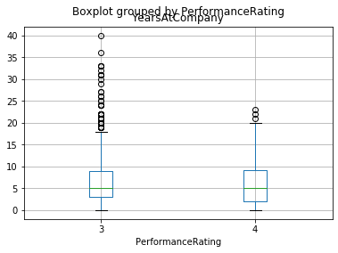

```python
perf_vs_exp("YearsAtCompany")
```

Visually, Years at Company does not make a huge impact on Performance Score. The little impact we do see indicates that those with more years with the company tend to have lower performance score.

### Total Working Years

```
Let's take a look at how TotalWorkingYears varies based on Performance Rating


When the rating is 3:
count    805.000000
mean      11.388820
std        7.834998
min        0.000000
25%        6.000000
50%       10.000000
75%       16.000000
max       40.000000
Name: TotalWorkingYears, dtype: float64


When the rating is 4:
count    156.000000
mean      11.102564
std        7.620160
min        1.000000
25%        5.750000
50%       10.000000
75%       15.000000
max       36.000000
Name: TotalWorkingYears, dtype: float64


Now let's see what this relationship looks like plotted
TotalWorkingYears    (AxesSubplot(0.1,0.15;0.8x0.75), {'whiskers': ...
dtype: object
```

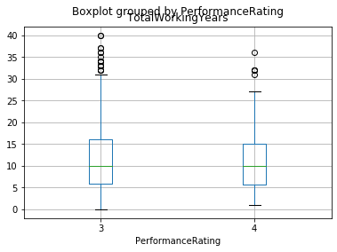

```python
perf_vs_exp("TotalWorkingYears")
```

I don't see a significant difference visually between the number of years worked and performance score.

### Years In Current Role

```
Let's take a look at how YearsInCurrentRole varies based on Performance Rating


When the rating is 3:
count    805.000000
mean       4.171429
std        3.626249
min        0.000000
25%        2.000000
50%        3.000000
75%        7.000000
max       18.000000
Name: YearsInCurrentRole, dtype: float64


When the rating is 4:
count    156.000000
mean       4.070513
std        3.757336
min        0.000000
25%        1.750000
50%        3.000000
75%        7.000000
max       16.000000
Name: YearsInCurrentRole, dtype: float64


Now let's see what this relationship looks like plotted
YearsInCurrentRole    (AxesSubplot(0.1,0.15;0.8x0.75), {'whiskers': ...
dtype: object
```

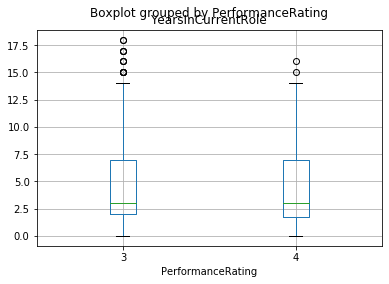

```python
perf_vs_exp("YearsInCurrentRole")
```

Once more, the difference seems mostly negligible.

### Num Companies Worked

```
Let's take a look at how NumCompaniesWorked varies based on Performance Rating


When the rating is 3:
count    805.000000
mean       2.731677
std        2.524517
min        0.000000
25%        1.000000
50%        2.000000
75%        4.000000
max        9.000000
Name: NumCompaniesWorked, dtype: float64


When the rating is 4:
count    156.000000
mean       2.743590
std        2.395888
min        0.000000
25%        1.000000
50%        2.000000
75%        4.000000
max        9.000000
Name: NumCompaniesWorked, dtype: float64


Now let's see what this relationship looks like plotted
NumCompaniesWorked    (AxesSubplot(0.1,0.15;0.8x0.75), {'whiskers': ...
dtype: object
```

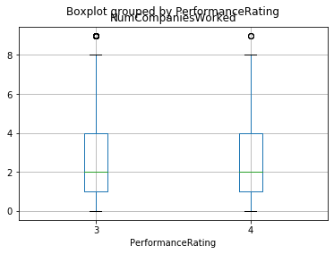

```python
perf_vs_exp("NumCompaniesWorked")
```

Not much difference at all can be seen for this metric either.

### Education

```
Let's take a look at how Education varies based on Performance Rating


When the rating is 3:
count    805.000000
mean       2.909317
std        1.028439
min        1.000000
25%        2.000000
50%        3.000000
75%        4.000000
max        5.000000
Name: Education, dtype: float64


When the rating is 4:
count    156.000000
mean       2.846154
std        1.004210
min        1.000000
25%        2.000000
50%        3.000000
75%        4.000000
max        5.000000
Name: Education, dtype: float64


Now let's see what this relationship looks like plotted
Education    (AxesSubplot(0.1,0.15;0.8x0.75), {'whiskers': ...
dtype: object
```

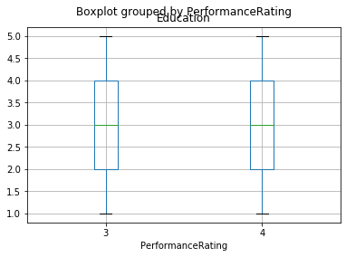

```python
perf_vs_exp("Education")
```

Another feature without much change on Performance Score.

### Job Satisfaction

```
Let's take a look at how JobSatisfaction varies based on Performance Rating


When the rating is 3:
count    805.000000
mean       2.732919
std        1.093614
min        1.000000
25%        2.000000
50%        3.000000
75%        4.000000
max        4.000000
Name: JobSatisfaction, dtype: float64


When the rating is 4:
count    156.000000
mean       2.692308
std        1.145062
min        1.000000
25%        2.000000
50%        3.000000
75%        4.000000
max        4.000000
Name: JobSatisfaction, dtype: float64


Now let's see what this relationship looks like plotted
JobSatisfaction    (AxesSubplot(0.1,0.15;0.8x0.75), {'whiskers': ...
dtype: object
```

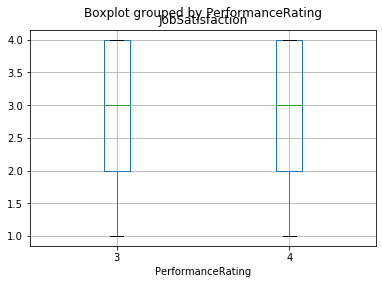

```python
perf_vs_exp("JobSatisfaction")
```

I was also curious to see how a person's job satisfaction score affects their performance. Turns out, the effect even here is negligible.

## Logistic Regression

### Data Prep

**We are creating a model which predicts whether the performance score was a 4 or not.** Considering, we only have folks with 3 or 4 as their performance score, we can easily one hot encode this variable.

```python
# These are the features I wish to convert into a one hot encoded featurs for the model
dum_cols = ["Attrition","BusinessTravel","EducationField","Gender","MaritalStatus","OverTime","PerformanceRating"]

# Dropping these since they either lack variaton, are not useful, or have too many categories
drop_cols = ["Department", "EmployeeCount","EmployeeNumber","JobRole","Over18","StandardHours"]

# identifying our label column as a Boolean of whether the person has a rating of 4
label_col = "PerformanceRating_4"
```

```python
# creating a new copy for data
model_data = data.copy()
```

```python
model_data.drop(drop_cols,axis=1,inplace=True)
```

```python
model_data = pd.get_dummies(model_data,columns=dum_cols,drop_first=True)
```

```python
X = model_data.drop(label_col,axis=1)
y = model_data[label_col]
```

```python
from sklearn.model_selection import train_test_split

# Splitting our data into test and train
X_train, X_test, y_train, y_test = train_test_split(X, y, test_size=0.33, random_state=2019)
```

```python
from sklearn.preprocessing import StandardScaler

# Scaling the data so our model's feature coefficients are standrdized
scaler = StandardScaler()
X_train = scaler.fit_transform(X_train)
X_test = scaler.transform(X_test)
```

```python
from sklearn.linear_model import LogisticRegression

# Creating and fitting the log reg model
log_model = LogisticRegression()
log_model.fit(X_train, y_train)
preds = log_model.predict(X_test)
```

```python
from sklearn.metrics import classification_report, confusion_matrix
```

```python
# Evaluating results
print(classification_report(y_test,preds))
```

```
              precision    recall  f1-score   support

           0       0.98      0.98      0.98       273
           1       0.89      0.87      0.88        45

    accuracy                           0.97       318
   macro avg       0.93      0.92      0.93       318
weighted avg       0.97      0.97      0.97       318
```

```python
print(confusion_matrix(y_test,preds))
```

```
[[268   5]
 [  6  39]]
```

```python
from IPython.display import Markdown as md
acc = (preds==y_test).mean()
md(f"Our logistic regression model is able to predict the performance score with a high accuracy of {round(acc,4)*100}%. Now, let us see which of our features played the biggest hand. ")
```

Our logistic regression model is able to predict the performance score with a high accuracy of 96.54%. Now, let us see which of our features played the biggest hand.

```python
feat_coef = pd.DataFrame({"feature":X.columns,"coef":log_model.coef_[0]})
feat_coef.sort_values(by="coef",ascending=False)
```

|  | feature | coef |
| --- | --- | --- |
| 12 | PercentSalaryHike | 4.366146 |
| 19 | YearsInCurrentRole | 0.386538 |
| 27 | EducationField_Technical Degree | 0.254588 |
| 23 | BusinessTravel_Travel_Frequently | 0.203325 |
| 22 | Attrition_Yes | 0.186008 |
| 28 | Gender_Male | 0.142566 |
| 3 | Education | 0.086963 |
| 7 | JobLevel | 0.044155 |
| 11 | NumCompaniesWorked | 0.027360 |
| 0 | Age | 0.012209 |
| 5 | HourlyRate | 0.004463 |
| 13 | RelationshipSatisfaction | -0.001239 |
| 14 | StockOptionLevel | -0.006934 |
| 21 | YearsWithCurrManager | -0.018098 |
| 15 | TotalWorkingYears | -0.034407 |
| 17 | WorkLifeBalance | -0.034450 |
| 10 | MonthlyRate | -0.036429 |
| 4 | EnvironmentSatisfaction | -0.040273 |
| 26 | EducationField_Other | -0.043791 |
| 29 | MaritalStatus_Married | -0.047802 |
| 9 | MonthlyIncome | -0.116288 |
| 24 | BusinessTravel_Travel_Rarely | -0.122729 |
| 31 | OverTime_Yes | -0.130558 |
| 20 | YearsSinceLastPromotion | -0.142672 |
| 30 | MaritalStatus_Single | -0.145840 |
| 25 | EducationField_Medical | -0.165742 |
| 1 | DailyRate | -0.166119 |
| 2 | DistanceFromHome | -0.174035 |
| 6 | JobInvolvement | -0.202051 |
| 8 | JobSatisfaction | -0.238393 |
| 16 | TrainingTimesLastYear | -0.248522 |
| 18 | YearsAtCompany | -0.380238 |

### Explanation

It is of no surprise that percent salary hike played a huge role in predicting performance score. However, we want to look at the experience features which the R&D head believe are correlated with performance. It turns out that the Head's claims are quite to the contrary. For instance, a higher number of years at the company (YearsAtCompany) was more indicative of a lower performance score.

Meanwhile, total working years had no effect on performance score. Interestingly however, a person's year in current role did make a the second highest impact on performance score. Therefore, those who have been at their current position for a while are likely to be performing well in the company. This could be a sign of problems with firm when it comes to promoting employees to appropriate positions for their skill set.

Returning to the head's point, her beliefs that more experience is tied with performance is not founded based on my analysis.

# 4. Identify Risk Prone Subset

*Identify at least one subset of employees who are at disproportionate risk for leaving based on the data provided. (Hint: It may be helpful to use pivot tables for your analysis.) (15 points)*

```python
print("Current attrition for the R&D department is", round(model_data.Attrition_Yes.mean(),4)*100,"%")
```

```
Current attrition for the R&D department is 13.84 %
```

Let's use logistic regression again to identify which variables are most strongly linked and not linked with attrition.

## Logistic Regression

### Data Prep

**We are creating a model which predicts whether the person left the company or not.**

```python
# These are the features I wish to convert into a one hot encoded featurs for the model
dum_cols = ["Attrition","BusinessTravel","EducationField","Gender","MaritalStatus","OverTime","PerformanceRating"]

# Dropping these since they either lack variaton, are not useful, or have too many categories
drop_cols = ["Department", "EmployeeCount","EmployeeNumber","JobRole","Over18","StandardHours"]

# identifying our label column as a Boolean of whether the person has a rating of 4
label_col = "Attrition_Yes"
```

```python
# creating a new copy for data
model_data = data.copy()
```

```python
model_data.drop(drop_cols,axis=1,inplace=True)
```

```python
model_data = pd.get_dummies(model_data,columns=dum_cols,drop_first=True)
```

```python
X = model_data.drop(label_col,axis=1)
y = model_data[label_col]
```

```python
# Splitting our data into test and train
X_train, X_test, y_train, y_test = train_test_split(X, y, test_size=0.33, random_state=2019)
```

```python
from sklearn.preprocessing import StandardScaler

# Scaling the data so our model's feature coefficients are standrdized
scaler = StandardScaler()
X_train = scaler.fit_transform(X_train)
X_test = scaler.transform(X_test)
```

```python
from sklearn.linear_model import LogisticRegression

# Creating and fitting the log reg model
log_model = LogisticRegression()
log_model.fit(X_train, y_train)
preds = log_model.predict(X_test)
```

```python
from sklearn.metrics import classification_report, confusion_matrix
```

```python
# Evaluating results
print(classification_report(y_test,preds))
```

```
              precision    recall  f1-score   support

           0       0.90      0.99      0.94       277
           1       0.79      0.27      0.40        41

    accuracy                           0.90       318
   macro avg       0.84      0.63      0.67       318
weighted avg       0.89      0.90      0.87       318
```

```python
print(confusion_matrix(y_test,preds))
```

```
[[274   3]
 [ 30  11]]
```

```python
from IPython.display import Markdown as md
acc = (preds==y_test).mean()
md(f"Our logistic regression model is able to predict the attrition with ah accuracy of {round(acc,4)*100}%. Now, let us see which of our features played the biggest hand. ")
```

Our logistic regression model is able to predict the attrition with ah accuracy of 89.62%. Now, let us see which of our features played the biggest hand.

```python
feat_coef = pd.DataFrame({"feature":X.columns,"coef":log_model.coef_[0]})
feat_coef.sort_values(by="coef",ascending=False)
```

|  | feature | coef |
| --- | --- | --- |
| 30 | OverTime_Yes | 0.818905 |
| 20 | YearsSinceLastPromotion | 0.591246 |
| 22 | BusinessTravel_Travel_Frequently | 0.486565 |
| 11 | NumCompaniesWorked | 0.459248 |
| 2 | DistanceFromHome | 0.436901 |
| 29 | MaritalStatus_Single | 0.412167 |
| 31 | PerformanceRating_4 | 0.382363 |
| 23 | BusinessTravel_Travel_Rarely | 0.358455 |
| 18 | YearsAtCompany | 0.341974 |
| 26 | EducationField_Technical Degree | 0.264460 |
| 27 | Gender_Male | 0.201458 |
| 28 | MaritalStatus_Married | 0.141888 |
| 25 | EducationField_Other | 0.088000 |
| 5 | HourlyRate | 0.035491 |
| 24 | EducationField_Medical | 0.035385 |
| 1 | DailyRate | -0.034899 |
| 21 | YearsWithCurrManager | -0.045998 |
| 3 | Education | -0.073834 |
| 10 | MonthlyRate | -0.130847 |
| 16 | TrainingTimesLastYear | -0.142795 |
| 14 | StockOptionLevel | -0.145466 |
| 7 | JobLevel | -0.252179 |
| 6 | JobInvolvement | -0.282909 |
| 0 | Age | -0.292398 |
| 15 | TotalWorkingYears | -0.312921 |
| 13 | RelationshipSatisfaction | -0.320091 |
| 17 | WorkLifeBalance | -0.323056 |
| 9 | MonthlyIncome | -0.370176 |
| 8 | JobSatisfaction | -0.396588 |
| 12 | PercentSalaryHike | -0.421541 |
| 4 | EnvironmentSatisfaction | -0.537959 |
| 19 | YearsInCurrentRole | -0.683860 |

Based on this information, we can begin to identify subsets which may need to be addressed for attrition.

## Subset 1: Employees working overtime

Overtime working staff seems to be the highest at risk for leaving the company as it is the strongest variable for predicting a true attrition label. Hence, these persons need to be given more of a break during the work week or they will be overworked. This will most likely lead to them leaving as the analysis indicates

## Subset 2: High Performing Employees who haven't been promoted in more than 2 years

As the second strongest variable which leads to attrition of an employee, the firm needs to promote those who are performing well and are long due a promotion.

```python
# Calculating how many employees with high performance have been promoted in the last 2 years
(data[data.PerformanceRating==4].YearsSinceLastPromotion <= 2).value_counts()
```

```
True     120
False     36
Name: YearsSinceLastPromotion, dtype: int64
```

Out of 156 high performing employees, 120 have been promoted in the last couple of years. 36 personnel however have not been promoted. Let's look at how those 36 stack up in terms of years since last promotion.

```python
(data[(data.PerformanceRating==4) & (data.YearsSinceLastPromotion>2)]).YearsSinceLastPromotion.value_counts()
```

```
3     8
5     6
11    5
7     4
4     4
6     3
12    2
8     2
14    1
13    1
Name: YearsSinceLastPromotion, dtype: int64
```

We can note here that there are a good chunk of high performing folks who haven't been promoted in more than 5 years, some even at 11 years. Keep in mind also that a high performance rating is also a stronger contributing variable towards attrition. The combination of both high performing and a lot of years since last promotion is crucial for the firm. This subset is something that R&D head will need to address to prevent losing this talent.

```python
print("Here are the employee numbers of those at risk of leaving in this subset:","\n",(data[(data.PerformanceRating==4) & (data.YearsSinceLastPromotion>2)]).EmployeeNumber.values)
```

```
Here are the employee numbers of those at risk of leaving in this subset:
 [  33   57   78  119  145  264  292  343  367  442  605  692  807  880
  958 1035 1092 1101 1184 1225 1237 1241 1375 1665 1666 1675 1693 1712
 1821 1854 1905 1936 1956 1979 1993 2017]
```

## Subset 3: Employees with low satisfaction

High environment, relationship, work life balance and job satisfaction ratings are linked with lower attrition. Hence, staff which have concerns in these areas need to be resolved by management.

## Other general subsets

According to our logistic regression, persons who travel for business frequently, have a higher distance from home, are single or have worked for more companies are also at a higher risk of leaving.

## Bonus: How are high performing employees rewarded comparatively to lower ones?

The firm currently does a great job of rewarding those with higher scores with higher salary hikes. Take a look below:

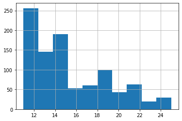

```python
# Here is the distribution of Percent salary hike overall
data.PercentSalaryHike.hist()
```

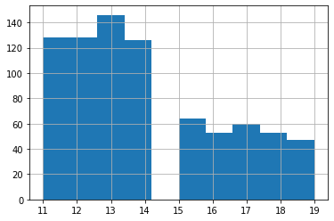

```python
# Distribution of percent salary hike for those with 3 performance rating
data[data.PerformanceRating==3].PercentSalaryHike.hist()
```

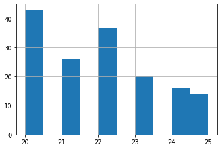

```python
# Distribution of percent salary hike for those with 4 performance rating
data[data.PerformanceRating==4].PercentSalaryHike.hist()
```

# 5. Addressing the Risk Factors

*What recommendations would you make to the head of R&D to address the risk factors for attrition that you identified in Q3? (15 points)*

**Assumption: This question actually refers to Q4 and not Q3 as that is where we looked at what impacts attrition**

# 6. Testing Recommendation's Rapid Effectiveness

*For one of your recommendations, how would you design a rapid experiment to learn whether your recommendation successfully mitigates attrition? What other information would you want to track and how would you track and report it? (15 points)*

```python
# There are currently 271 R&D employees which work overtime
data.OverTime.value_counts()
```

```
No     690
Yes    271
Name: OverTime, dtype: int64
```

There will be 100 participants who will not be aware of the experiment's existence (in order to prevent bias). The experiment will be designed in a way where 100 employees who work over time will be selected. All of the individuals not in the control group will no longer be designated to work overtime. There will be 30 individuals in the control group. Two surveys will be performed. One at the start of the experiment and one at the end of the month.

The core foundation of this experiment is past research which links job satisfaction to lower attrition. [source](http://www.iaeme.com/MasterAdmin/UploadFolder/IJMET_08_12_092/IJMET_08_12_092.pdf)

The hypothesis: **Lack of overtime leads to higher satisfaction with work**

Both the control and experimental group will take both the start and ending surveys. Confounding variables such as age, education, geographical location, etc. will be addressed thought stratified sampling based on these variables. Hence, the experimental and control groups will contain samples of our population which is as consistently represented as possible across the demographic variables mentioned earlier.

The surveys will address questions which relate to overall satisfaction of the employee with their work. Here are some examples of questions / data points we will collect on the survey:

- How likely are you to recommend working at this firm to a friend on a scale of 1-10?
- How well are you able to balance your life and work on a scale of 1-10?
- Has an excess amount of work led you to miss out on your personal activities?
- How well do you enjoy your work on a scale of 1-10?
- How excited do you feel coming to work every day in a scale of 1-10?
- What is the most exciting part of your work day?
- Can you write about a recent project that you enjoyed working on?

Questions such as these will allow us evaluate the satisfaction rating more in depth. Asking these before and after the experiment will allow us to collect and gauge the employee's sentiment towards work. We will conduct regression on these data points as well between the experimental and control groups to evaluate the effect of no overtime on job satisfaction. Also note that we will perform sentiment analysis on how the participant writes about their recent project and track it over time to see if there is a significant change.

Lastly, I would report the results of this experiment in the form of a white paper to the head of R&D listing all the findings with charts. Naturally, I will also include my recommendations based on the findings as well. I will also relay my findings to other departments in the firm which may be struggling with the same issues.